# Risk Factor Analysis

## Outcome Variable

**Outcome Variable:** ever_stunted

## Predictor Variables

**Intervention Variable:** single

**Adjustment Set:**

unadjusted

## Stratifying Variables

The analysis was stratified on these variable(s):

- agecat
- studyid
- country

## Data Summary

| agecat | studyid | country | single | ever_stunted | n_cell | n |
| --- | --- | --- | --- | --- | --- | --- |
| 0-24 months | COHORTS | GUATEMALA | 0 | 0 | 254 | 1207 |
| 0-24 months | COHORTS | GUATEMALA | 0 | 1 | 855 | 1207 |
| 0-24 months | COHORTS | GUATEMALA | 1 | 0 | 12 | 1207 |
| 0-24 months | COHORTS | GUATEMALA | 1 | 1 | 86 | 1207 |
| 0-24 months | COHORTS | INDIA | 0 | 0 | 3293 | 5384 |
| 0-24 months | COHORTS | INDIA | 0 | 1 | 2082 | 5384 |
| 0-24 months | COHORTS | INDIA | 1 | 0 | 4 | 5384 |
| 0-24 months | COHORTS | INDIA | 1 | 1 | 5 | 5384 |
| 0-24 months | COHORTS | PHILIPPINES | 0 | 0 | 924 | 3018 |
| 0-24 months | COHORTS | PHILIPPINES | 0 | 1 | 2019 | 3018 |
| 0-24 months | COHORTS | PHILIPPINES | 1 | 0 | 21 | 3018 |
| 0-24 months | COHORTS | PHILIPPINES | 1 | 1 | 54 | 3018 |
| 0-24 months | Guatemala BSC | GUATEMALA | 0 | 0 | 118 | 282 |
| 0-24 months | Guatemala BSC | GUATEMALA | 0 | 1 | 134 | 282 |
| 0-24 months | Guatemala BSC | GUATEMALA | 1 | 0 | 8 | 282 |
| 0-24 months | Guatemala BSC | GUATEMALA | 1 | 1 | 22 | 282 |
| 0-24 months | MAL-ED | BANGLADESH | 0 | 0 | 103 | 265 |
| 0-24 months | MAL-ED | BANGLADESH | 0 | 1 | 162 | 265 |
| 0-24 months | MAL-ED | BANGLADESH | 1 | 0 | 0 | 265 |
| 0-24 months | MAL-ED | BANGLADESH | 1 | 1 | 0 | 265 |
| 0-24 months | MAL-ED | BRAZIL | 0 | 0 | 148 | 233 |
| 0-24 months | MAL-ED | BRAZIL | 0 | 1 | 49 | 233 |
| 0-24 months | MAL-ED | BRAZIL | 1 | 0 | 22 | 233 |
| 0-24 months | MAL-ED | BRAZIL | 1 | 1 | 14 | 233 |
| 0-24 months | MAL-ED | INDIA | 0 | 0 | 99 | 249 |
| 0-24 months | MAL-ED | INDIA | 0 | 1 | 150 | 249 |
| 0-24 months | MAL-ED | INDIA | 1 | 0 | 0 | 249 |
| 0-24 months | MAL-ED | INDIA | 1 | 1 | 0 | 249 |
| 0-24 months | MAL-ED | NEPAL | 0 | 0 | 156 | 240 |
| 0-24 months | MAL-ED | NEPAL | 0 | 1 | 84 | 240 |

[output cut: 138 more lines]

The following strata were considered:

- agecat: 0-24 months, studyid: COHORTS, country: GUATEMALA
- agecat: 0-24 months, studyid: COHORTS, country: INDIA
- agecat: 0-24 months, studyid: COHORTS, country: PHILIPPINES
- agecat: 0-24 months, studyid: Guatemala BSC, country: GUATEMALA
- agecat: 0-24 months, studyid: MAL-ED, country: BANGLADESH
- agecat: 0-24 months, studyid: MAL-ED, country: BRAZIL
- agecat: 0-24 months, studyid: MAL-ED, country: INDIA
- agecat: 0-24 months, studyid: MAL-ED, country: NEPAL
- agecat: 0-24 months, studyid: MAL-ED, country: PERU
- agecat: 0-24 months, studyid: MAL-ED, country: SOUTH AFRICA
- agecat: 0-24 months, studyid: MAL-ED, country: TANZANIA, UNITED REPUBLIC OF
- agecat: 0-24 months, studyid: PROBIT, country: BELARUS
- agecat: 0-24 months, studyid: TanzaniaChild2, country: TANZANIA, UNITED REPUBLIC OF
- agecat: 0-24 months, studyid: ZVITAMBO, country: ZIMBABWE
- agecat: 0-6 months, studyid: COHORTS, country: GUATEMALA
- agecat: 0-6 months, studyid: COHORTS, country: INDIA
- agecat: 0-6 months, studyid: COHORTS, country: PHILIPPINES
- agecat: 0-6 months, studyid: Guatemala BSC, country: GUATEMALA
- agecat: 0-6 months, studyid: MAL-ED, country: BANGLADESH
- agecat: 0-6 months, studyid: MAL-ED, country: BRAZIL
- agecat: 0-6 months, studyid: MAL-ED, country: INDIA
- agecat: 0-6 months, studyid: MAL-ED, country: NEPAL
- agecat: 0-6 months, studyid: MAL-ED, country: PERU
- agecat: 0-6 months, studyid: MAL-ED, country: SOUTH AFRICA
- agecat: 0-6 months, studyid: MAL-ED, country: TANZANIA, UNITED REPUBLIC OF
- agecat: 0-6 months, studyid: PROBIT, country: BELARUS
- agecat: 0-6 months, studyid: TanzaniaChild2, country: TANZANIA, UNITED REPUBLIC OF
- agecat: 0-6 months, studyid: ZVITAMBO, country: ZIMBABWE
- agecat: 6-24 months, studyid: COHORTS, country: GUATEMALA
- agecat: 6-24 months, studyid: COHORTS, country: INDIA
- agecat: 6-24 months, studyid: COHORTS, country: PHILIPPINES
- agecat: 6-24 months, studyid: Guatemala BSC, country: GUATEMALA
- agecat: 6-24 months, studyid: MAL-ED, country: BANGLADESH
- agecat: 6-24 months, studyid: MAL-ED, country: BRAZIL
- agecat: 6-24 months, studyid: MAL-ED, country: INDIA
- agecat: 6-24 months, studyid: MAL-ED, country: NEPAL
- agecat: 6-24 months, studyid: MAL-ED, country: PERU
- agecat: 6-24 months, studyid: MAL-ED, country: SOUTH AFRICA
- agecat: 6-24 months, studyid: MAL-ED, country: TANZANIA, UNITED REPUBLIC OF
- agecat: 6-24 months, studyid: PROBIT, country: BELARUS
- agecat: 6-24 months, studyid: TanzaniaChild2, country: TANZANIA, UNITED REPUBLIC OF
- agecat: 6-24 months, studyid: ZVITAMBO, country: ZIMBABWE

### Dropped Strata

Some strata were dropped due to rare outcomes:

- agecat: 0-24 months, studyid: COHORTS, country: INDIA
- agecat: 0-24 months, studyid: MAL-ED, country: BANGLADESH
- agecat: 0-24 months, studyid: MAL-ED, country: INDIA
- agecat: 0-24 months, studyid: MAL-ED, country: NEPAL
- agecat: 0-24 months, studyid: MAL-ED, country: TANZANIA, UNITED REPUBLIC OF
- agecat: 0-6 months, studyid: COHORTS, country: INDIA
- agecat: 0-6 months, studyid: MAL-ED, country: BANGLADESH
- agecat: 0-6 months, studyid: MAL-ED, country: INDIA
- agecat: 0-6 months, studyid: MAL-ED, country: NEPAL
- agecat: 0-6 months, studyid: MAL-ED, country: TANZANIA, UNITED REPUBLIC OF
- agecat: 6-24 months, studyid: COHORTS, country: INDIA
- agecat: 6-24 months, studyid: MAL-ED, country: BANGLADESH
- agecat: 6-24 months, studyid: MAL-ED, country: BRAZIL
- agecat: 6-24 months, studyid: MAL-ED, country: INDIA
- agecat: 6-24 months, studyid: MAL-ED, country: NEPAL
- agecat: 6-24 months, studyid: MAL-ED, country: TANZANIA, UNITED REPUBLIC OF

## Methods Detail

We’re interested in the causal parameters $E[Y_a]$ for all values of $a \in \mathcal{A}$. These parameters represent the mean outcome if, possibly contrary to fact, we intervened to set all units to have $A=a$. Under the randomization and positivity assumptions, these are identified by the statistical parameters $\psi_a=E_W[E_{Y|A,W}(Y|A=a,W)]$. In addition, we’re interested in the mean of $Y$, $E[Y]$ under no intervention (the observed mean). We will estimate these parameters by using SuperLearner to fit the relevant likelihood factors – $E_{Y|A,W}(Y|A=a,W)$ and $p(A=a|W)$, and then updating our likelihood fit using a joint TMLE.

For unadjusted analyses ($W=\{\}$), initial likelihoods were estimated using Lrnr_glm to estimate the simple $E(Y|A)$ and Lrnr_mean to estimate $p(A)$. For adjusted analyses, a small library containing Lrnr_glmnet, Lrnr_xgboost, and Lrnr_mean was used.

Having estimated these parameters, we will then use the delta method to estimate relative risks and attributable risks relative to a prespecified baseline level of $A$.

# Results Detail

## Results Plots

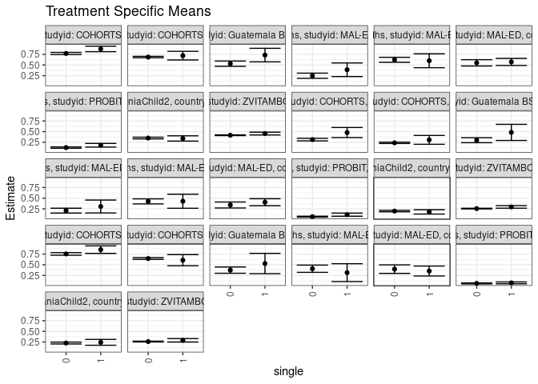

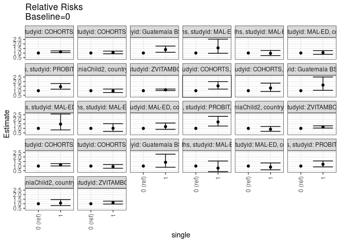

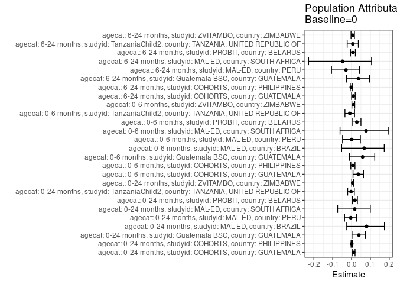

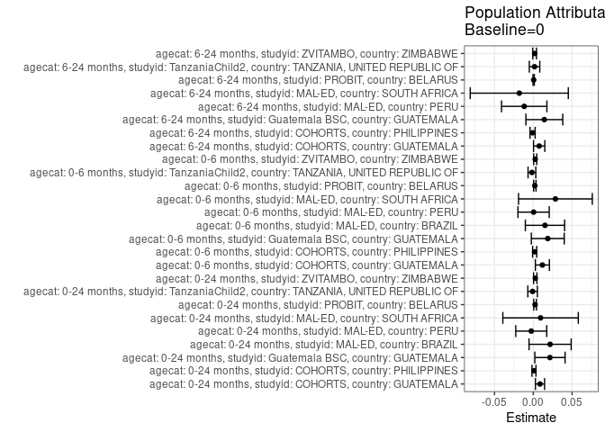

## Results Table

### Parameter: TSM

| agecat | studyid | country | intervention_level | baseline_level | estimate | ci_lower | ci_upper |
| --- | --- | --- | --- | --- | --- | --- | --- |
| 0-24 months | COHORTS | GUATEMALA | 0 | NA | 0.7709648 | 0.7462231 | 0.7957066 |
| 0-24 months | COHORTS | GUATEMALA | 1 | NA | 0.8775510 | 0.8126235 | 0.9424785 |
| 0-24 months | COHORTS | PHILIPPINES | 0 | NA | 0.6860347 | 0.6692619 | 0.7028074 |
| 0-24 months | COHORTS | PHILIPPINES | 1 | NA | 0.7200000 | 0.6189732 | 0.8210268 |
| 0-24 months | Guatemala BSC | GUATEMALA | 0 | NA | 0.5317460 | 0.4700280 | 0.5934641 |
| 0-24 months | Guatemala BSC | GUATEMALA | 1 | NA | 0.7333333 | 0.5748097 | 0.8918569 |
| 0-24 months | MAL-ED | BRAZIL | 0 | NA | 0.2487310 | 0.1882371 | 0.3092249 |
| 0-24 months | MAL-ED | BRAZIL | 1 | NA | 0.3888889 | 0.2292996 | 0.5484782 |
| 0-24 months | MAL-ED | PERU | 0 | NA | 0.6231343 | 0.5650201 | 0.6812486 |
| 0-24 months | MAL-ED | PERU | 1 | NA | 0.6000000 | 0.4374311 | 0.7625689 |
| 0-24 months | MAL-ED | SOUTH AFRICA | 0 | NA | 0.5511364 | 0.4775375 | 0.6247352 |
| 0-24 months | MAL-ED | SOUTH AFRICA | 1 | NA | 0.5724638 | 0.4897912 | 0.6551364 |
| 0-24 months | PROBIT | BELARUS | 0 | NA | 0.1251543 | 0.1094268 | 0.1408818 |
| 0-24 months | PROBIT | BELARUS | 1 | NA | 0.1803752 | 0.1378520 | 0.2228983 |
| 0-24 months | TanzaniaChild2 | TANZANIA, UNITED REPUBLIC OF | 0 | NA | 0.3491399 | 0.3289905 | 0.3692894 |
| 0-24 months | TanzaniaChild2 | TANZANIA, UNITED REPUBLIC OF | 1 | NA | 0.3392857 | 0.2772695 | 0.4013019 |
| 0-24 months | ZVITAMBO | ZIMBABWE | 0 | NA | 0.4147178 | 0.4062895 | 0.4231461 |
| 0-24 months | ZVITAMBO | ZIMBABWE | 1 | NA | 0.4544432 | 0.4217112 | 0.4871752 |
| 0-6 months | COHORTS | GUATEMALA | 0 | NA | 0.3127072 | 0.2824877 | 0.3429266 |
| 0-6 months | COHORTS | GUATEMALA | 1 | NA | 0.4782609 | 0.3603359 | 0.5961858 |
| 0-6 months | COHORTS | PHILIPPINES | 0 | NA | 0.2368332 | 0.2214685 | 0.2521978 |
| 0-6 months | COHORTS | PHILIPPINES | 1 | NA | 0.3066667 | 0.2029148 | 0.4104185 |
| 0-6 months | Guatemala BSC | GUATEMALA | 0 | NA | 0.2983193 | 0.2400834 | 0.3565553 |
| 0-6 months | Guatemala BSC | GUATEMALA | 1 | NA | 0.4814815 | 0.2926566 | 0.6703063 |
| 0-6 months | MAL-ED | BRAZIL | 0 | NA | 0.2081218 | 0.1513102 | 0.2649334 |
| 0-6 months | MAL-ED | BRAZIL | 1 | NA | 0.3055556 | 0.1547579 | 0.4563532 |
| 0-6 months | MAL-ED | PERU | 0 | NA | 0.4253731 | 0.3660838 | 0.4846625 |
| 0-6 months | MAL-ED | PERU | 1 | NA | 0.4285714 | 0.2643520 | 0.5927908 |
| 0-6 months | MAL-ED | SOUTH AFRICA | 0 | NA | 0.3409091 | 0.2707674 | 0.4110508 |
| 0-6 months | MAL-ED | SOUTH AFRICA | 1 | NA | 0.4057971 | 0.3237387 | 0.4878555 |
| 0-6 months | PROBIT | BELARUS | 0 | NA | 0.0666708 | 0.0559250 | 0.0774166 |
| 0-6 months | PROBIT | BELARUS | 1 | NA | 0.1139971 | 0.0776445 | 0.1503497 |
| 0-6 months | TanzaniaChild2 | TANZANIA, UNITED REPUBLIC OF | 0 | NA | 0.1975825 | 0.1807521 | 0.2144129 |
| 0-6 months | TanzaniaChild2 | TANZANIA, UNITED REPUBLIC OF | 1 | NA | 0.1785714 | 0.1284058 | 0.2287371 |
| 0-6 months | ZVITAMBO | ZIMBABWE | 0 | NA | 0.2563301 | 0.2488567 | 0.2638035 |
| 0-6 months | ZVITAMBO | ZIMBABWE | 1 | NA | 0.2953777 | 0.2653537 | 0.3254017 |
| 6-24 months | COHORTS | GUATEMALA | 0 | NA | 0.7546174 | 0.7239651 | 0.7852698 |
| 6-24 months | COHORTS | GUATEMALA | 1 | NA | 0.8548387 | 0.7671013 | 0.9425761 |
| 6-24 months | COHORTS | PHILIPPINES | 0 | NA | 0.6461388 | 0.6254001 | 0.6668775 |
| 6-24 months | COHORTS | PHILIPPINES | 1 | NA | 0.6078431 | 0.4774592 | 0.7382270 |
| 6-24 months | Guatemala BSC | GUATEMALA | 0 | NA | 0.3750000 | 0.3015949 | 0.4484051 |
| 6-24 months | Guatemala BSC | GUATEMALA | 1 | NA | 0.5294118 | 0.2914989 | 0.7673246 |
| 6-24 months | MAL-ED | PERU | 0 | NA | 0.4076923 | 0.3229347 | 0.4924499 |
| 6-24 months | MAL-ED | PERU | 1 | NA | 0.3157895 | 0.1060755 | 0.5255034 |
| 6-24 months | MAL-ED | SOUTH AFRICA | 0 | NA | 0.3978495 | 0.2980571 | 0.4976418 |
| 6-24 months | MAL-ED | SOUTH AFRICA | 1 | NA | 0.3538462 | 0.2372336 | 0.4704587 |
| 6-24 months | PROBIT | BELARUS | 0 | NA | 0.0637825 | 0.0521024 | 0.0754627 |
| 6-24 months | PROBIT | BELARUS | 1 | NA | 0.0761589 | 0.0543382 | 0.0979797 |
| 6-24 months | TanzaniaChild2 | TANZANIA, UNITED REPUBLIC OF | 0 | NA | 0.2262318 | 0.2046228 | 0.2478408 |
| 6-24 months | TanzaniaChild2 | TANZANIA, UNITED REPUBLIC OF | 1 | NA | 0.2432432 | 0.1740996 | 0.3123869 |
| 6-24 months | ZVITAMBO | ZIMBABWE | 0 | NA | 0.2612895 | 0.2516448 | 0.2709342 |
| 6-24 months | ZVITAMBO | ZIMBABWE | 1 | NA | 0.2903885 | 0.2501521 | 0.3306250 |

### Parameter: E(Y)

| agecat | studyid | country | intervention_level | baseline_level | estimate | ci_lower | ci_upper |
| --- | --- | --- | --- | --- | --- | --- | --- |
| 0-24 months | COHORTS | GUATEMALA | NA | NA | 0.7796189 | 0.7562250 | 0.8030128 |
| 0-24 months | COHORTS | PHILIPPINES | NA | NA | 0.6868787 | 0.6703303 | 0.7034272 |
| 0-24 months | Guatemala BSC | GUATEMALA | NA | NA | 0.5531915 | 0.4950624 | 0.6113206 |
| 0-24 months | MAL-ED | BRAZIL | NA | NA | 0.2703863 | 0.2132328 | 0.3275398 |
| 0-24 months | MAL-ED | PERU | NA | NA | 0.6204620 | 0.5657315 | 0.6751926 |
| 0-24 months | MAL-ED | SOUTH AFRICA | NA | NA | 0.5605096 | 0.5055248 | 0.6154943 |
| 0-24 months | PROBIT | BELARUS | NA | NA | 0.1274191 | 0.1115552 | 0.1432829 |
| 0-24 months | TanzaniaChild2 | TANZANIA, UNITED REPUBLIC OF | NA | NA | 0.3482105 | 0.3290467 | 0.3673744 |
| 0-24 months | ZVITAMBO | ZIMBABWE | NA | NA | 0.4172374 | 0.4090737 | 0.4254012 |
| 0-6 months | COHORTS | GUATEMALA | NA | NA | 0.3244353 | 0.2950189 | 0.3538517 |
| 0-6 months | COHORTS | PHILIPPINES | NA | NA | 0.2385686 | 0.2233602 | 0.2537770 |
| 0-6 months | Guatemala BSC | GUATEMALA | NA | NA | 0.3169811 | 0.2608532 | 0.3731091 |
| 0-6 months | MAL-ED | BRAZIL | NA | NA | 0.2231760 | 0.1695976 | 0.2767543 |
| 0-6 months | MAL-ED | PERU | NA | NA | 0.4257426 | 0.3699763 | 0.4815088 |
| 0-6 months | MAL-ED | SOUTH AFRICA | NA | NA | 0.3694268 | 0.3159570 | 0.4228965 |
| 0-6 months | PROBIT | BELARUS | NA | NA | 0.0686124 | 0.0577768 | 0.0794479 |
| 0-6 months | TanzaniaChild2 | TANZANIA, UNITED REPUBLIC OF | NA | NA | 0.1957895 | 0.1798275 | 0.2117515 |
| 0-6 months | ZVITAMBO | ZIMBABWE | NA | NA | 0.2588042 | 0.2515487 | 0.2660597 |
| 6-24 months | COHORTS | GUATEMALA | NA | NA | 0.7621951 | 0.7330377 | 0.7913526 |
| 6-24 months | COHORTS | PHILIPPINES | NA | NA | 0.6452074 | 0.6247246 | 0.6656902 |
| 6-24 months | Guatemala BSC | GUATEMALA | NA | NA | 0.3891892 | 0.3187405 | 0.4596379 |
| 6-24 months | MAL-ED | PERU | NA | NA | 0.3959732 | 0.3171819 | 0.4747644 |
| 6-24 months | MAL-ED | SOUTH AFRICA | NA | NA | 0.3797468 | 0.3038314 | 0.4556622 |
| 6-24 months | PROBIT | BELARUS | NA | NA | 0.0642659 | 0.0526827 | 0.0758490 |
| 6-24 months | TanzaniaChild2 | TANZANIA, UNITED REPUBLIC OF | NA | NA | 0.2278162 | 0.2071874 | 0.2484451 |
| 6-24 months | ZVITAMBO | ZIMBABWE | NA | NA | 0.2629713 | 0.2535901 | 0.2723525 |

### Parameter: RR

| agecat | studyid | country | intervention_level | baseline_level | estimate | ci_lower | ci_upper |
| --- | --- | --- | --- | --- | --- | --- | --- |
| 0-24 months | COHORTS | GUATEMALA | 0 | 0 | 1.0000000 | 1.0000000 | 1.000000 |
| 0-24 months | COHORTS | GUATEMALA | 1 | 0 | 1.1382504 | 1.0500576 | 1.233850 |
| 0-24 months | COHORTS | PHILIPPINES | 0 | 0 | 1.0000000 | 1.0000000 | 1.000000 |
| 0-24 months | COHORTS | PHILIPPINES | 1 | 0 | 1.0495097 | 0.9101862 | 1.210160 |
| 0-24 months | Guatemala BSC | GUATEMALA | 0 | 0 | 1.0000000 | 1.0000000 | 1.000000 |
| 0-24 months | Guatemala BSC | GUATEMALA | 1 | 0 | 1.3791045 | 1.0790454 | 1.762603 |
| 0-24 months | MAL-ED | BRAZIL | 0 | 0 | 1.0000000 | 1.0000000 | 1.000000 |
| 0-24 months | MAL-ED | BRAZIL | 1 | 0 | 1.5634921 | 0.9703415 | 2.519224 |
| 0-24 months | MAL-ED | PERU | 0 | 0 | 1.0000000 | 1.0000000 | 1.000000 |
| 0-24 months | MAL-ED | PERU | 1 | 0 | 0.9628743 | 0.7229741 | 1.282379 |
| 0-24 months | MAL-ED | SOUTH AFRICA | 0 | 0 | 1.0000000 | 1.0000000 | 1.000000 |
| 0-24 months | MAL-ED | SOUTH AFRICA | 1 | 0 | 1.0386971 | 0.8532288 | 1.264481 |
| 0-24 months | PROBIT | BELARUS | 0 | 0 | 1.0000000 | 1.0000000 | 1.000000 |
| 0-24 months | PROBIT | BELARUS | 1 | 0 | 1.4412226 | 1.1634569 | 1.785303 |
| 0-24 months | TanzaniaChild2 | TANZANIA, UNITED REPUBLIC OF | 0 | 0 | 1.0000000 | 1.0000000 | 1.000000 |
| 0-24 months | TanzaniaChild2 | TANZANIA, UNITED REPUBLIC OF | 1 | 0 | 0.9717757 | 0.8022707 | 1.177094 |
| 0-24 months | ZVITAMBO | ZIMBABWE | 0 | 0 | 1.0000000 | 1.0000000 | 1.000000 |
| 0-24 months | ZVITAMBO | ZIMBABWE | 1 | 0 | 1.0957891 | 1.0167750 | 1.180943 |
| 0-6 months | COHORTS | GUATEMALA | 0 | 0 | 1.0000000 | 1.0000000 | 1.000000 |
| 0-6 months | COHORTS | GUATEMALA | 1 | 0 | 1.5294208 | 1.1735781 | 1.993159 |
| 0-6 months | COHORTS | PHILIPPINES | 0 | 0 | 1.0000000 | 1.0000000 | 1.000000 |
| 0-6 months | COHORTS | PHILIPPINES | 1 | 0 | 1.2948637 | 0.9175211 | 1.827393 |
| 0-6 months | Guatemala BSC | GUATEMALA | 0 | 0 | 1.0000000 | 1.0000000 | 1.000000 |
| 0-6 months | Guatemala BSC | GUATEMALA | 1 | 0 | 1.6139802 | 1.0414655 | 2.501218 |
| 0-6 months | MAL-ED | BRAZIL | 0 | 0 | 1.0000000 | 1.0000000 | 1.000000 |
| 0-6 months | MAL-ED | BRAZIL | 1 | 0 | 1.4681572 | 0.8352919 | 2.580518 |
| 0-6 months | MAL-ED | PERU | 0 | 0 | 1.0000000 | 1.0000000 | 1.000000 |
| 0-6 months | MAL-ED | PERU | 1 | 0 | 1.0075188 | 0.6701519 | 1.514722 |
| 0-6 months | MAL-ED | SOUTH AFRICA | 0 | 0 | 1.0000000 | 1.0000000 | 1.000000 |
| 0-6 months | MAL-ED | SOUTH AFRICA | 1 | 0 | 1.1903382 | 0.8920369 | 1.588393 |
| 0-6 months | PROBIT | BELARUS | 0 | 0 | 1.0000000 | 1.0000000 | 1.000000 |
| 0-6 months | PROBIT | BELARUS | 1 | 0 | 1.7098512 | 1.2568663 | 2.326096 |
| 0-6 months | TanzaniaChild2 | TANZANIA, UNITED REPUBLIC OF | 0 | 0 | 1.0000000 | 1.0000000 | 1.000000 |
| 0-6 months | TanzaniaChild2 | TANZANIA, UNITED REPUBLIC OF | 1 | 0 | 0.9037815 | 0.6738650 | 1.212143 |
| 0-6 months | ZVITAMBO | ZIMBABWE | 0 | 0 | 1.0000000 | 1.0000000 | 1.000000 |
| 0-6 months | ZVITAMBO | ZIMBABWE | 1 | 0 | 1.1523333 | 1.0367013 | 1.280863 |
| 6-24 months | COHORTS | GUATEMALA | 0 | 0 | 1.0000000 | 1.0000000 | 1.000000 |
| 6-24 months | COHORTS | GUATEMALA | 1 | 0 | 1.1328107 | 1.0144231 | 1.265015 |
| 6-24 months | COHORTS | PHILIPPINES | 0 | 0 | 1.0000000 | 1.0000000 | 1.000000 |
| 6-24 months | COHORTS | PHILIPPINES | 1 | 0 | 0.9407315 | 0.7573059 | 1.168584 |
| 6-24 months | Guatemala BSC | GUATEMALA | 0 | 0 | 1.0000000 | 1.0000000 | 1.000000 |
| 6-24 months | Guatemala BSC | GUATEMALA | 1 | 0 | 1.4117647 | 0.8647352 | 2.304844 |
| 6-24 months | MAL-ED | PERU | 0 | 0 | 1.0000000 | 1.0000000 | 1.000000 |
| 6-24 months | MAL-ED | PERU | 1 | 0 | 0.7745780 | 0.3862340 | 1.553387 |
| 6-24 months | MAL-ED | SOUTH AFRICA | 0 | 0 | 1.0000000 | 1.0000000 | 1.000000 |
| 6-24 months | MAL-ED | SOUTH AFRICA | 1 | 0 | 0.8893971 | 0.5878019 | 1.345738 |
| 6-24 months | PROBIT | BELARUS | 0 | 0 | 1.0000000 | 1.0000000 | 1.000000 |
| 6-24 months | PROBIT | BELARUS | 1 | 0 | 1.1940404 | 0.9104375 | 1.565986 |
| 6-24 months | TanzaniaChild2 | TANZANIA, UNITED REPUBLIC OF | 0 | 0 | 1.0000000 | 1.0000000 | 1.000000 |
| 6-24 months | TanzaniaChild2 | TANZANIA, UNITED REPUBLIC OF | 1 | 0 | 1.0751948 | 0.7966225 | 1.451182 |
| 6-24 months | ZVITAMBO | ZIMBABWE | 0 | 0 | 1.0000000 | 1.0000000 | 1.000000 |
| 6-24 months | ZVITAMBO | ZIMBABWE | 1 | 0 | 1.1113670 | 0.9629034 | 1.282721 |

### Parameter: PAR

| agecat | studyid | country | intervention_level | baseline_level | estimate | ci_lower | ci_upper |
| --- | --- | --- | --- | --- | --- | --- | --- |
| 0-24 months | COHORTS | GUATEMALA | 0 | NA | 0.0086541 | 0.0027782 | 0.0145299 |
| 0-24 months | COHORTS | PHILIPPINES | 0 | NA | 0.0008441 | -0.0017231 | 0.0034113 |
| 0-24 months | Guatemala BSC | GUATEMALA | 0 | NA | 0.0214455 | 0.0019436 | 0.0409473 |
| 0-24 months | MAL-ED | BRAZIL | 0 | NA | 0.0216553 | -0.0055081 | 0.0488187 |
| 0-24 months | MAL-ED | PERU | 0 | NA | -0.0026723 | -0.0226321 | 0.0172875 |
| 0-24 months | MAL-ED | SOUTH AFRICA | 0 | NA | 0.0093732 | -0.0392867 | 0.0580331 |
| 0-24 months | PROBIT | BELARUS | 0 | NA | 0.0022648 | 0.0005188 | 0.0040108 |
| 0-24 months | TanzaniaChild2 | TANZANIA, UNITED REPUBLIC OF | 0 | NA | -0.0009294 | -0.0070806 | 0.0052218 |
| 0-24 months | ZVITAMBO | ZIMBABWE | 0 | NA | 0.0025197 | 0.0003699 | 0.0046695 |
| 0-6 months | COHORTS | GUATEMALA | 0 | NA | 0.0117281 | 0.0027007 | 0.0207556 |
| 0-6 months | COHORTS | PHILIPPINES | 0 | NA | 0.0017354 | -0.0009152 | 0.0043860 |
| 0-6 months | Guatemala BSC | GUATEMALA | 0 | NA | 0.0186618 | -0.0025515 | 0.0398751 |
| 0-6 months | MAL-ED | BRAZIL | 0 | NA | 0.0150541 | -0.0102527 | 0.0403610 |
| 0-6 months | MAL-ED | PERU | 0 | NA | 0.0003694 | -0.0197986 | 0.0205375 |
| 0-6 months | MAL-ED | SOUTH AFRICA | 0 | NA | 0.0285177 | -0.0190598 | 0.0760951 |
| 0-6 months | PROBIT | BELARUS | 0 | NA | 0.0019416 | 0.0004271 | 0.0034560 |
| 0-6 months | TanzaniaChild2 | TANZANIA, UNITED REPUBLIC OF | 0 | NA | -0.0017930 | -0.0067886 | 0.0032025 |
| 0-6 months | ZVITAMBO | ZIMBABWE | 0 | NA | 0.0024741 | 0.0005074 | 0.0044409 |
| 6-24 months | COHORTS | GUATEMALA | 0 | NA | 0.0075777 | 0.0003202 | 0.0148352 |
| 6-24 months | COHORTS | PHILIPPINES | 0 | NA | -0.0009314 | -0.0042416 | 0.0023789 |
| 6-24 months | Guatemala BSC | GUATEMALA | 0 | NA | 0.0141892 | -0.0095805 | 0.0379589 |
| 6-24 months | MAL-ED | PERU | 0 | NA | -0.0117192 | -0.0409824 | 0.0175441 |
| 6-24 months | MAL-ED | SOUTH AFRICA | 0 | NA | -0.0181026 | -0.0813351 | 0.0451299 |
| 6-24 months | PROBIT | BELARUS | 0 | NA | 0.0004833 | -0.0003373 | 0.0013039 |
| 6-24 months | TanzaniaChild2 | TANZANIA, UNITED REPUBLIC OF | 0 | NA | 0.0015845 | -0.0051672 | 0.0083361 |
| 6-24 months | ZVITAMBO | ZIMBABWE | 0 | NA | 0.0016818 | -0.0007139 | 0.0040775 |

### Parameter: PAF

| agecat | studyid | country | intervention_level | baseline_level | estimate | ci_lower | ci_upper |
| --- | --- | --- | --- | --- | --- | --- | --- |
| 0-24 months | COHORTS | GUATEMALA | 0 | NA | 0.0111004 | 0.0034904 | 0.0186522 |
| 0-24 months | COHORTS | PHILIPPINES | 0 | NA | 0.0012288 | -0.0025160 | 0.0049598 |
| 0-24 months | Guatemala BSC | GUATEMALA | 0 | NA | 0.0387668 | 0.0025234 | 0.0736932 |
| 0-24 months | MAL-ED | BRAZIL | 0 | NA | 0.0800902 | -0.0255546 | 0.1748524 |
| 0-24 months | MAL-ED | PERU | 0 | NA | -0.0043069 | -0.0370022 | 0.0273575 |
| 0-24 months | MAL-ED | SOUTH AFRICA | 0 | NA | 0.0167226 | -0.0740643 | 0.0998356 |
| 0-24 months | PROBIT | BELARUS | 0 | NA | 0.0177743 | 0.0040926 | 0.0312681 |
| 0-24 months | TanzaniaChild2 | TANZANIA, UNITED REPUBLIC OF | 0 | NA | -0.0026691 | -0.0204908 | 0.0148414 |
| 0-24 months | ZVITAMBO | ZIMBABWE | 0 | NA | 0.0060390 | 0.0008725 | 0.0111787 |
| 0-6 months | COHORTS | GUATEMALA | 0 | NA | 0.0361494 | 0.0079334 | 0.0635629 |
| 0-6 months | COHORTS | PHILIPPINES | 0 | NA | 0.0072743 | -0.0038953 | 0.0183197 |
| 0-6 months | Guatemala BSC | GUATEMALA | 0 | NA | 0.0588735 | -0.0103760 | 0.1233768 |
| 0-6 months | MAL-ED | BRAZIL | 0 | NA | 0.0674541 | -0.0525149 | 0.1737487 |
| 0-6 months | MAL-ED | PERU | 0 | NA | 0.0008678 | -0.0476446 | 0.0471337 |
| 0-6 months | MAL-ED | SOUTH AFRICA | 0 | NA | 0.0771944 | -0.0610580 | 0.1974329 |
| 0-6 months | PROBIT | BELARUS | 0 | NA | 0.0282978 | 0.0060993 | 0.0500005 |
| 0-6 months | TanzaniaChild2 | TANZANIA, UNITED REPUBLIC OF | 0 | NA | -0.0091580 | -0.0349928 | 0.0160318 |
| 0-6 months | ZVITAMBO | ZIMBABWE | 0 | NA | 0.0095598 | 0.0019327 | 0.0171286 |
| 6-24 months | COHORTS | GUATEMALA | 0 | NA | 0.0099420 | 0.0003332 | 0.0194583 |
| 6-24 months | COHORTS | PHILIPPINES | 0 | NA | -0.0014435 | -0.0065875 | 0.0036742 |
| 6-24 months | Guatemala BSC | GUATEMALA | 0 | NA | 0.0364583 | -0.0266802 | 0.0957140 |
| 6-24 months | MAL-ED | PERU | 0 | NA | -0.0295958 | -0.1063031 | 0.0417928 |
| 6-24 months | MAL-ED | SOUTH AFRICA | 0 | NA | -0.0476703 | -0.2282350 | 0.1063494 |
| 6-24 months | PROBIT | BELARUS | 0 | NA | 0.0075205 | -0.0055168 | 0.0203887 |
| 6-24 months | TanzaniaChild2 | TANZANIA, UNITED REPUBLIC OF | 0 | NA | 0.0069550 | -0.0231251 | 0.0361507 |
| 6-24 months | ZVITAMBO | ZIMBABWE | 0 | NA | 0.0063952 | -0.0027559 | 0.0154629 |